# Projekt 2 - Wstęp do uczenia maszynowego

Joanna Gajewska, Olaf Werner, Bogdan Jastrzębski

6 June 2019

# 1 Wstęp

Niniejszy raport poświęcony jest opisowi procesu analizy “unsupervised” zbioru danych, dotyczącego zachowania dzieci odwiedzających Centrum nauki Kopernik.

Zajmiemy się:

- analizą unsupervised całego zbioru
- analizą unsupervised podzbiorów i znalezieniu między nimi zależności

# 2 Opis zbioru danych

Zbiór pochodzący z SWPS ma na celu opisać zachowania dzieci podczas zwiedzania Centrum nauki Kopernik. Zbiór składa się z dwóch ramek danych “po osobach” i “obserwacje”. Jeden z nich dotyczy obserwacji jakie zarejestrowano w trakcie wizyty w CNK - Obserwacje_nowe.xlsx, kolejny dataset - Po_osobach.xlsx odnosi się do informacji jakie zebrano w ankietach przed i po zwiedzaniu, a także podsumowujące wrażenia odwiedziających.

## 2.1 “Obserwacje”

W pierwszej kolejności omówimy zbiór danych zawarty w pliku Obserwacje_nowe. Są to pomiary wykonywane w interwałach czasowych ok. 20 min, mające na celu ustalić wrażenia i zachowanie zwiedzających w danych przedziałach czasowych.

- numer wydarzenia odpowiada za ID każdego wiersza
- każdy wiersz ma przypisany mu odowiadająco nr badanej pary (opiekun-dziecko) oraz nr badacza
- kategoria wydarzenia (1- eksponat, 2- pomiar nastroju i zmęczenia, 3- inne (przerwa, toaleta itp.))
- nr pomiaru interwału czasowegow trakcie pobytu w CNK
- pomiar zmęczenia i nastroju, oceniane w skali 1-9 oraz czas mierzenia nastroju
- ilość kroków rozpoczętych z lewej i prawej nogi w danym interwale czasowym
- galeria oraz eksponat na trasie zwiedzających
- w sali 0-1 mierzono zainteresowanie zwiedzjących wystawę (czyta, dotyka, używa itp)
- zapytano uczestników czy chcą kontunować zwiedzanie po zakończeniu programu, następnie ponownie rejestrowano ich zachowanie (podpunkt wyżej)

Pierwsze wiersze:

| no | obserwator | ID | nr_wydarzenia | kategoria_wyd | Nastr_nr | R_nastroj | R_zmeczenie | D_nastroj | D_zmęczenie | kroki_L | kroki_P | Nastr_kiedy | interwal_dlugosc | interwal_kroki_L | interwal_kroki_P | eksponat_Nr | Galeria | Nazwa eksponatu | poznawcze | D_woła | D_pyta | D_patrzy | patrzy_ktos | D_dotyka | R_dotyka | D_używa | R_używa | czas_min_sec | time_s | … |
| --- | --- | --- | --- | --- | --- | --- | --- | --- | --- | --- | --- | --- | --- | --- | --- | --- | --- | --- | --- | --- | --- | --- | --- | --- | --- | --- | --- | --- | --- | --- |
| 1 | 4 | 45 | 1 | 2 | 0 | 8 | 1 | 9 | 1 | 0 | 0 | 1899-12-31 13:36:00 | NA | 0 | 0 | NA | NA | NA | NA | NA | NA | NA | NA | NA | NA | NA | NA | NA | NA | … |
| 2 | 4 | 45 | 2 | 1 | NA | NA | NA | NA | NA | NA | NA | NA | NA | NA | NA | 1 | AGORA | wahadło foucaulta | 1 | 0 | 1 | 1 | 0 | 0 | 0 | 0 | 0 | 1899-12-31 00:11:20 | 680 | … |
| 3 | 4 | 45 | 3 | 3 | NA | NA | NA | NA | NA | NA | NA | NA | NA | NA | NA | NA | INNE | ława interkatywna | NA | NA | NA | NA | NA | NA | NA | NA | NA | 1899-12-31 00:01:50 | 110 | … |
| 4 | 4 | 45 | 4 | 1 | NA | NA | NA | NA | NA | NA | NA | NA | NA | NA | NA | 2 | CZŁOWIEK I ŚRODOWISKO | miniwarsztat | 2 | NA | NA | NA | NA | NA | NA | NA | NA | 1899-12-31 00:02:25 | 145 | … |
| 5 | 4 | 45 | 5 | 1 | NA | NA | NA | NA | NA | NA | NA | NA | NA | NA | NA | 3 | CZŁOWIEK I ŚRODOWISKO | sztuka rysowania | 1 | 1 | 0 | 1 | 0 | 0 | 0 | 0 | 0 | 1899-12-31 00:00:15 | 15 | … |
| 6 | 4 | 45 | 6 | 1 | NA | NA | NA | NA | NA | NA | NA | NA | NA | NA | NA | 4 | CZŁOWIEK I ŚRODOWISKO | jest ryzyko, jest zabawa | 1 | 0 | 0 | 1 | 0 | 0 | 0 | 0 | 0 | 1899-12-31 00:03:10 | 190 | … |

Jak widać dane są sekwencyjne. W nieokreślonych interwałach rejestrowany był nastrój uczestników podczas ich wycieczki. Naszym zadaniem będzie odpowiednio zsumaryzować te dane.

Oto rozkłady naszych zmiennych:

- zmienne numeryczne:

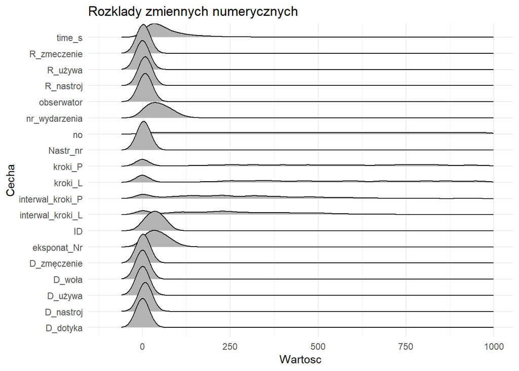

Zmienne kategoryczne:

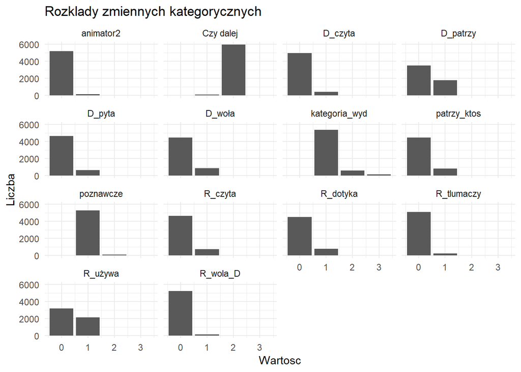

Pozostałe:

```
##  Inne zachowania       Uwagi            czas_min_sec
##  Length:6060        Length:6060        Min.   :1899-12-31 00:00:01
##  Class :character   Class :character   1st Qu.:1899-12-31 00:00:27
##  Mode  :character   Mode  :character   Median :1899-12-31 00:00:50
##                                        Mean   :1899-12-31 00:01:30
##                                        3rd Qu.:1899-12-31 00:01:35
##                                        Max.   :1899-12-31 00:42:18
##                                        NA's   :604
##   Nastr_kiedy                  interwal_dlugosc
##  Min.   :1899-12-31 09:10:00   Min.   :1899-12-31 00:06:00
##  1st Qu.:1899-12-31 11:20:00   1st Qu.:1899-12-31 00:20:00
##  Median :1899-12-31 12:59:00   Median :1899-12-31 00:21:00
##  Mean   :1899-12-31 13:12:24   Mean   :1899-12-31 00:21:45
##  3rd Qu.:1899-12-31 15:02:00   3rd Qu.:1899-12-31 00:23:00
##  Max.   :1899-12-31 19:00:00   Max.   :1899-12-31 00:48:00
##  NA's   :5484                  NA's   :5556
##    Galeria          Nazwa eksponatu
##  Length:6060        Length:6060
##  Class :character   Class :character
##  Mode  :character   Mode  :character
##
##
##
##
```

## 2.2 “Po osobach”

2.2 “Po osobach” W kolejnym kroku opiszemy zawartość datasetu Po_osobach.

- za ID każdego rekordu odpowiada nr osoby badanej
- data pomiaru - rok 2016, styczeń
- seria pytań dotycząca nastawienia opiekuna do wizyty w CNK ( zainteresowanie, chęć zdobycia wiedzy, oczekiwania odnośnie dziecka i tego co z niej wyniesie) skala: 1- zdecydowanie się nie zgadzam, 7 - zdecydowanie się zgadzam
- pytania odnoszące się do zachowania dziecka na wystawie(grzeczne, ruchliwe, skoncentrowane itp), skala: 1- zdecydowanie się nie zgadzam, 7 - zdecydowanie się zgadzam
- uczucia jakie towrzyszyły w trakcie zwiedzania (radość, smutek, złość, zrelaksowanie, zdenerwowanie itd.) skala 1- b. rzadko, 4 - b.często
- dane zawierające informacje o płci, wieku opiekuna i dziecka oraz miejsce zamieszkania, wyksztalcenie opiekuna
- relacja opiekun- dziecko (np. rodzic)
- atrybuty EAS - kwestionariusz temperamentu dzieci, ocenianych przez opiekunów w kategoriach : emocjonalność, aktywność, towarzyskość, nieśmiałość
- zbiór pytań dotyczący wrażeń po wycieczce w CNK (chęć kontynowania zwiedzania, czy planują kolejne wizyty, poziom zadowolenia) skala 1- zdecydowanie tak,…, 5-zdecydowanie nie
- poziom zmęczenia fizycznego i psychicznego
- opinie opiekunów na temat przygtowania wystawy pod kątem dzieci, czy była wystarczająco zrozumiała, prosta w obsłudze, czy wybór eksponatów był odpowiedni itp. skala: zdecydowanie nie zgadzam się-1,…, 7-zdecydowanie zgadzam się
- pytania skierowane do dzieci, odnośnie ich wrażeń i zachowania podczas wystawy ( czy im się podobało, czy byli grzeczni, co nowego się dowiedzieli, czy chcieliby jeszcze odwiedzić CNK itd.)
- atrybuty odpowiadająca 6 typom oddziaływań rodzicielskich :akceptacji, odrzuceniu, autonomii, nadmiernego wymagania, niekonsekwencji, nadmiernego ochraniania

Kilka pierwszych wierszy:

obserwator

DATA

P1

P1.1

P2

P2_chca_zobaczyc

P3_1

P3_2

P3_3

P3_4

P3_5

P3_6

P3_7

P3_8

P3_9

P3_10

P4_1

P4_2

P4_3

P4_4

P4_5

P4_6

P4_7

P4_8

P4_9

M1

M2

M3

M4

M4a

M4b

D1

D2

D2_a

D3

D3_kto

EAS_1

EAS_2

EAS_3

EAS_4

EAS_5

EAS_6

EAS_7

EAS_8

EAS_9

EAS_10

EAS_11

EAS_12

EAS_13

EAS_14

EAS_15

EAS_16

EAS_17

EAS_18

EAS_19

EAS_20

EAS_7_r

EAS_17_r

EAS_16_r

EAS_8_r

EAS_12_r

EAS_20_r

EAS_EMO

EAS_AKTYW

EAS_TOW

EAS_NIESM

R2.1

R2.1_1

R2.1_2

R2.2

R2.3

R2.4

R2.5

R2.6_1

R2.6_2

R2.6_3

R2.6_4

R2.6_5

R2.6_6

R2.6_7

R2.6_8

R2.6_9

R2.6_10

R2.6_11

R2.6_12

R2.6_13

R2.6_14

R2.7

R2.8

R2.9

D2.1

D2.2

D2.3

D2.4

D2.5

D2.6

D2.7

D2.8

D2.9_1

D2.9_1_dlaczego

D2.9_2

D2.9_2_dlaczego

D2.9_3

D2.9_3_dlaczego

D2.10

D2.11_1

D2.11_2

D2.12_1

D2.12_2

SPR_0

SPR_1

SPR_2

SPR_3

SPR_4

SPR_5

SPR_6

SPR_7

SPR_8

SPR_9

SPR_10

SPR_11

SPR_12

SPR_13

SPR_14

SPR_15

SPR_16

SPR_17

SPR_18

SPR_19

SPR_20

SPR_21

SPR_22

SPR_23

SPR_24

SPR_25

SPR_26

SPR_27

SPR_28

SPR_29

SPR_30

SPR_31

SPR_32

SPR_33

SPR_34

SPR_35

SPR_36

SPR_37

SPR_38

SPR_39

SPR_40

SPR_41

SPR_42

SPR_43

SPR_44

SPR_45

SPR_46

SPR_47

SPR_48

SPR_49

SPR_50

SPR_AKC_ODRZ

SPR_AUTONOMIA

SPR_OCHR

SPR_WYMAG

SPR_NIEKONS

1

1

11

05.01.2016

5

12

1

NA

5

7

6

7

7

5

7

3

5

7

5

5

4

4

4

4

3

4

2

1

1971

01-652

7

4

1

1

2008

4

1

NA

4

2

5

4

2

4

3

4

2

4

2

5

4

2

2

2

4

5

5

5

3

2

4

2

1

1

15

15

20

10

2

7

zmęczenie

2

2

1

4

5

5

2

6

6

4

1

2

6

3

7

2

6

7

60

7

7

3

4

2

1

3

2

1

3

Pijany kierowca

podobało mi się, że mogłam sobie kierować

Gorący balon

że go puszczałam i leciał

NA

NA

4

religia

z moją nauczycielką

angielski

WF

1

5

1

4

2

2

5

1

5

3

2

5

1

4

3

1

5

1

5

2

3

5

1

5

4

2

5

1

4

2

4

5

4

4

2

4

5

4

4

2

4

5

4

5

2

1

5

4

5

2

2

50

45

25

22

24

2

2

11

05.01.2016

3

16

2

Harfę, teatr robotyczny

7

7

7

7

7

6

7

7

1

4

4

3

4

5

4

5

5

1

4

1

1987

01-934

7

4

1

2

2008

6

2

ciocia

4

1

3

5

3

3

1

3

5

3

3

3

5

4

4

4

1

4

5

3

5

5

2

3

3

3

16

25

15

17

1

NA

NA

1

1

1

1

3

3

5

6

6

5

6

5

7

1

2

1

5

6

15

7

7

3

3

2

1

2

3

4

2

TEATR WYSOKICH NAPIĘĆ

Coś się dotyka i są zielone i niebieskie przy wejściu do teatru- wejście do TWN

grająca deseczka

NA

NA

NA

4

zajęcia sportowe

NA

muzyka

NA

1

5

1

5

4

2

4

2

5

3

2

5

2

4

1

4

4

2

5

1

1

5

1

5

2

2

5

1

5

2

1

5

2

5

2

2

5

2

5

1

2

5

3

5

1

1

5

1

5

1

1

48

49

18

17

18

3

3

14

5.01.2016

2

12

2

Harfę bez strun (Laserowa Harfa)

7

6

6

7

6

7

5

3

4

3

4

3

2

5

2

3

2

4

3

2

1986

02-790

7

4

1

2

2005

6

2

Przyjaciel rodziny

2

1

4

4

4

4

2

4

3

3

1

4

4

2

2

1

2

3

3

4

4

4

5

2

2

2

11

19

19

10

1

NA

NA

2

1

1

2

5

2

5

5

2

5

2

2

5

4

3

7

6

5

60

5

7

4

4

1

1

2

3

1

2

Laserowa harfa

jest to instrument w nowoczesnej odmianie

bieganie (3, 2, 1… start!)

NA

TEATR WYSOKICH NAPIĘĆ

dużo ciekawych i nowych rzeczy o prądzie

4

zajęcia sportowe

polski

angielski

Historia

2

3

4

4

3

4

5

3

4

3

5

5

3

3

3

4

5

2

4

3

2

4

1

5

2

4

5

1

3

2

3

4

2

2

1

4

4

4

4

2

3

5

3

5

2

4

5

3

5

3

4

45

39

37

26

24

4

4

14

5.01.2016

2

36

1

NA

5

7

6

6

6

5

5

5

5

5

4

3

4

5

4

2

3

3

2

2

1969

05-825

1

3

NA

1

2006

9

1

NA

3

3

2

2

4

1

2

3

4

3

2

3

3

2

2

2

2

4

1

2

4

4

4

3

3

4

9

17

17

15

1

NA

NA

1

1

1

2

2

2

6

7

5

5

3

5

6

5

4

5

5

5

60

7

7

4

3

1

1

1

2

2

2

Gorący balon

NA

Ukryta perspektywa

NA

NA

NA

4

Matematyka

plastyka

j.polski

Muzyka

2

4

2

5

3

2

3

3

4

3

2

4

4

5

3

1

3

4

5

3

2

4

1

4

2

4

5

3

4

4

2

5

3

5

4

1

4

3

3

3

2

4

4

5

2

2

4

3

5

1

1

40

45

19

30

28

5

5

12

05.01.2016

1

NA

2

Roboty, majsternia, pryzmaty, prąd

7

7

6

7

7

5

7

6

1

6

5

3

2

5

2

5

3

5

3

1

1978

26-900

3

4

2

2

2009

7

1

NA

1

3

5

5

5

4

3

5

3

3

4

5

5

2

4

3

1

1

1

5

3

5

3

1

1

1

16

21

17

6

1

NA

NA

1

1

1

2

6

7

7

7

5

7

6

4

7

5

4

7

5

7

60

7

7

4

4

1

1

1

3

1

3

majsternia

NA

Eksponat wodny

NA

NA

NA

4

10. polski

plastyka

Nie lubię śpiewać w kółeczku

NA

1

5

2

5

1

2

5

2

5

1

3

5

4

5

2

4

5

4

5

1

2

4

1

5

1

5

5

3

1

1

3

5

3

4

NA

3

5

2

3

2

1

5

4

3

1

2

5

2

5

1

2

49

41

27

27

11

6

6

2

05.01.2016

3

17

1

NA

7

7

7

7

7

3

5

7

1

5

5

2

3

5

3

5

4

2

3

1

1973

02-386

7

4

NA

2

2009

9

1

NA

2

3

5

5

5

5

1

4

4

3

2

4

5

2

4

1

1

3

3

4

5

5

5

2

2

2

17

24

21

10

1

NA

NA

2

1

1

3

5

1

7

7

7

5

2

5

2

6

6

2

7

2

75

7

7

4

4

1

1

1

4

2

2

Miniwarsztat Ogniwo Volty

NA

Wahadło Focaulta

NA

Robotespian

NA

4

Zajęcia plastyczne

Praca z książkami

żadnych

NA

1

4

2

3

5

2

5

2

5

2

3

5

3

5

3

2

5

2

5

3

2

4

5

5

2

5

5

2

2

1

1

5

5

5

3

2

5

3

5

3

3

4

2

5

2

4

3

4

4

2

2

45

44

26

30

26

# 3 Analiza podzbiorów

W tej części opiszemy analizę unsupervised ramki “Po Osobach” w podziale na podzbiory.

## 3.1 Motywacja

Dane w naszej ramce są logicznie podzielone. Część kolumn dotyczy np. tylko odpowiedzi dzieci, inne dotyczą odpowiedzi dorosłych w ankiecie, inne znowu dotyczą danych demograficznych itd. Analiza pewnego zbioru ma odpowiedzieć nam na pytanie, jakie są zależności między kolumnami tych grup.

Zaproponowaliśmy uproszczoną analizę, która ma wykazywać związki między całymi grupami.

## 3.2 Schemat testu

Test polega na:

- podzieleniu zbioru na podzbiory kolumn
- znalezieniu klas
- sprawdzeniu za pomocą testu $\chi^2$, czy dane klasy są ze sobą powiązane

## 3.3 Podzbiory

Oto nasze podzbiory:

- Dataset P: odpowiedzi na pytania skierowane do opiekunów, odnośnie ich oczekiwań co do wystawy i tego jak dziecko się zachowywało podczas zwiedzania.
- Dataset M: dane dotyczące opiekuna, wiek, miejsce zamieszkania, wykształcenie, płeć.
- Dataset D: dane dotyczące dziecka, wiek, płeć, relacja opiekun-dziecko
- Dataset EAS_r: charakterystyka cech temperamentu
- Dataset Eas_rest: opisują emocjonalnosć , towarzyskość, aktywność, nieśmiałość dziecka
- Dataset R: pytania skierowane do opiekuna odnośnie wrażeń po wystawie, o tym jak dziecko się zachowywało podczas zwiedzania, uwagi

## 3.4 Znalezienie klas

Do klasteryzacji wykorzystaliśmy algorytm hclust2. Oto drzewa dla naszych podzbiorów:

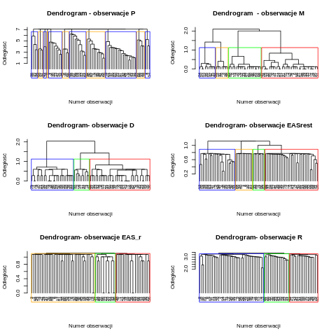

Na podstawie tych drzew dokonaliśmy podziału zbioru.

- R i P
- EASr i EASrest

**R i P**

Duże powiązanie zmiennych R i P jest oczywiste. Wynika to z tego, iż w pierwszym jak i w drugim zbiorze mamy do czynienia z odpowiedziami opiekunów na pytania związane z :

- ich oczekiwaniami odnośnie wystawy
- zachowaniem dzieci podczas zwiedzania
- wrażeniami po wystawie

Różnica między zbiorami :

- dla zbioru P odpowedzi były zbierane przed i w trakcie wycieczki
- zbiór R był stworzony na podstawie pytań po zakoczeniu wizyty

**EASr i EASrest**

Oba datasety dotyczą charakterystyki cech temperamentu, tyle, że są przedstawione w nieco inny sposób. Zatem powiązanie między nimi jest naturalne.

## 3.6 Dataset “Dzieci”"

Chcieliśmy zbadać dane dotyczące samych dzieci, więc ze zbioru danych wybraliśmy dane bezposrednio o dzieciach i połaczylismy je ze sobą. W ten sposób otrzymaliśmy dane o każdym z dziecku na temat tego, jak zachowywało się na wycieczce i jakie miało testy psychologiczne. Jedną z metod, których użyliśmy do grupowania dzieci, była metoda k-średnich.

Oto jak przedstawiaja się analiza podziałów po różnych k:

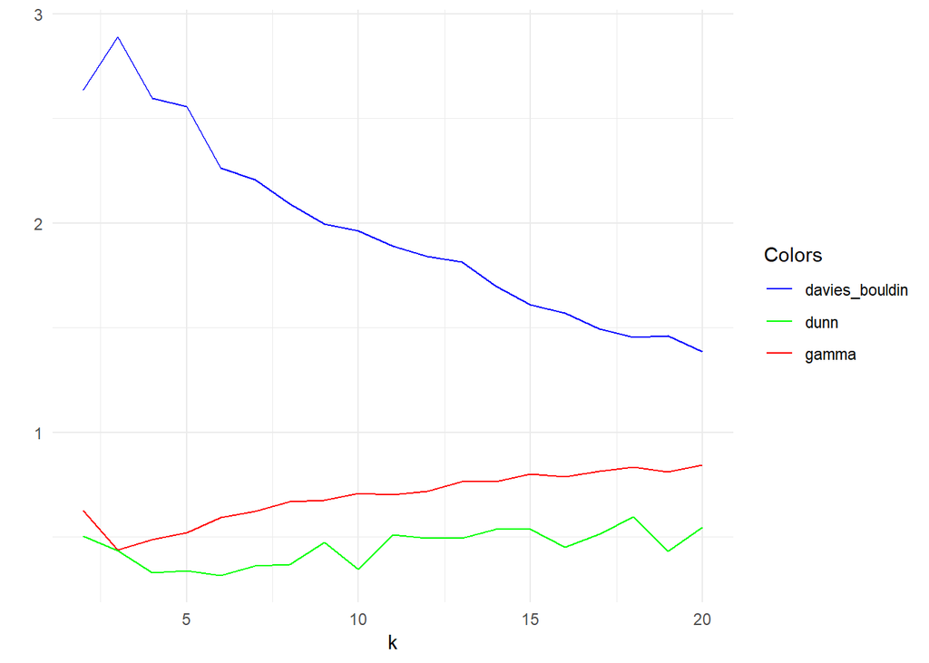

Jak widzimy, najbardziej sensowną liczbą klastrów okazała się liczba 20, ale z powodu tego, że nasz zbior liczy tylko 69 dzieci, to wzielismy 2 dla metody k-średnich.

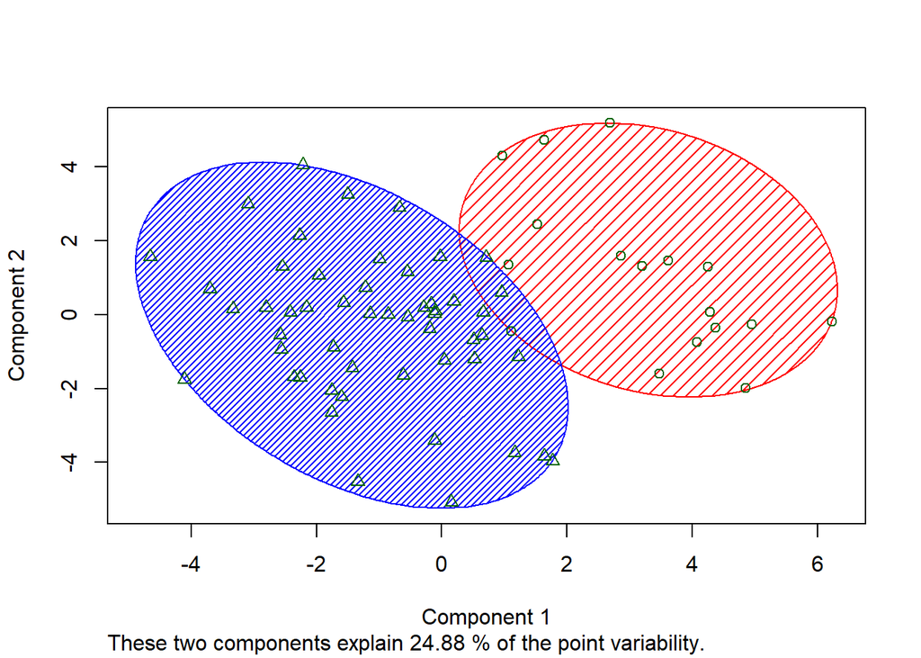

Mimo wyjaśniania tylko 24 procent wariancji, na wykresie PCA klastry są rozdzielalne wizualnie.

## 3.7 Czym sa komponenty?

Wykonaliśmy PCA i na podstawie macierzy rotacji zindentyfikowalismy najwazniejsze zmienne wchodzace w skład każdego z dwóch pierwszych wektorów.

```r
p1
```

```
##  [1] "P4_3"              "P4_5"              "P4_7"
##  [4] "P4_2"              "P4_1"              "P3_10"
##  [7] "P4_8"              "P3_7"              "EAS_EMO"
## [10] "D_nastroj_srednia"
```

```r
p2
```

```
##  [1] "krokow_na_minute" "kroki_L"          "kroki_P"
##  [4] "EAS_AKTYW"        "D2"               "P4_1"
##  [7] "D_uzywa"          "D1"               "P4_6"
## [10] "P2"
```

Po zapoznaniu sie z legendą, pierwszy wektor dotyczy psychiki dziecka, a drugi jego aktywnosci.

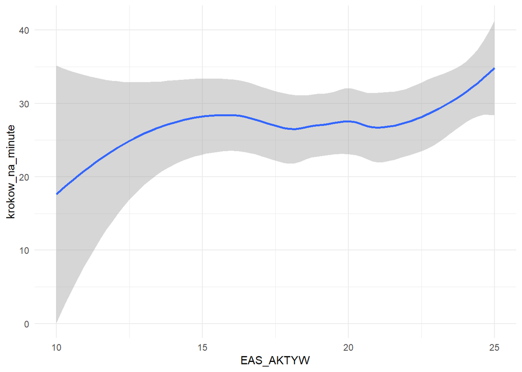

Istnieje pewna tendencja wzrostowa, ale z powodu małej ilości danych i możliwych błędów w krokomierzach istnieje duża niepewność wyniku.

# 4 Analiza unsupervised całego zbioru

W tej części będziemy sprawdzać jaki jest najoptymalniejszy podział dla naszego zbioru. Będziemy korzystać z następujących technik:

*a)* Metody :

- sylwetki
- łokcia
- ststystyki luki

*b)* Wewnętrzne indeksy :

- indek Dunn’a
- indeks Xie Beni
- indeks Davies’a Bouldin

Powyższe metody będziemy wykonywać dla metod klasteryzacji :

- k-średnich
- k-mediów (metoda grupowania wokół centroidów - PAM Partitioning Around Medoid)
- metoda hierarchiczna

**K-means:**

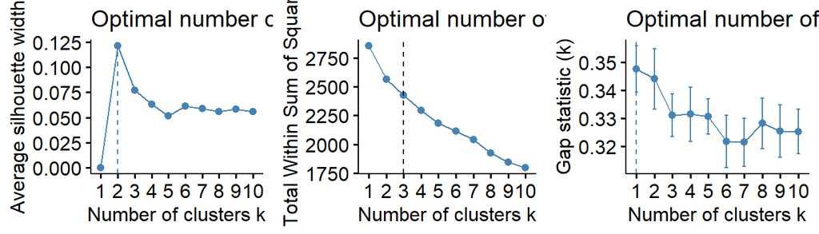

**PAM:**

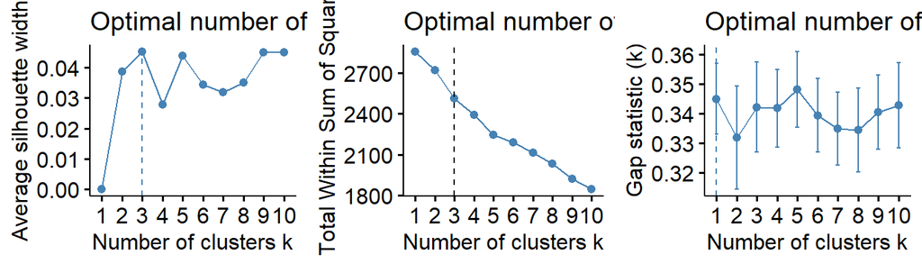

**hclust:**

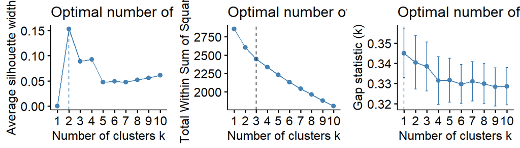

Analizując powyższe wykresy rzuca się w oczy, że dla wszystkich metod gap statistis daje podział rowny 1. Widać, że dla naszego przypadku ta metoda nie jest odpowiednia. Dla metody łokcia mamy prawie identyczne wykresy. Można wywnioskować, że jest to dosyć “płytka” metoda, nie wyłapująca subtelności wynikających z różnych sposobów klasteryzacji. Tak więc metoda sylwetki wydaje się być najrozsądniejsza dla naszego zbioru. Wskazuje ona dla k-średnich oraz dla metod hierarchicznych podział na 2 klasy, dla PAM są to 3 zbiory.

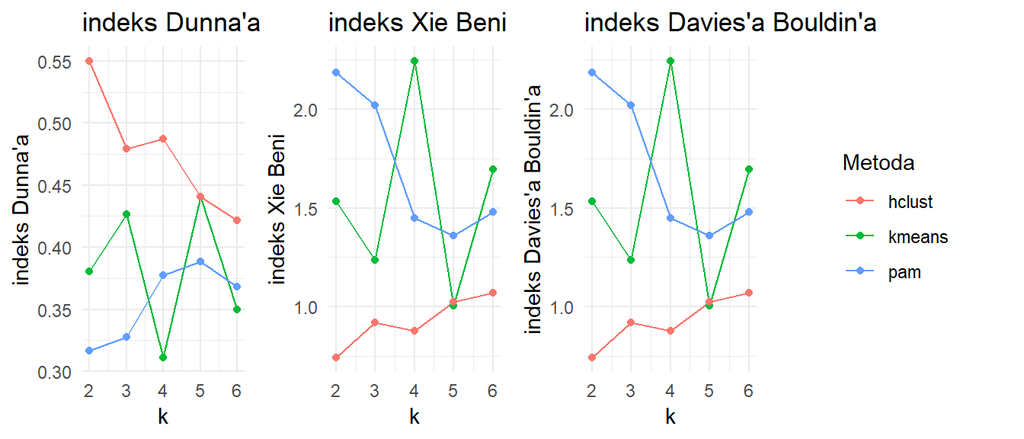

## 4.1 Wizualizacja klastrów

Z analizy otrzymanych wyników z metody sylwetki oraz indeksów, w wiekszości przypadków były wskazania na podział na 2 lub 3 grupy. Tak więc wykreślimy klastry dla tej liczby podziałów z osobna dla każdej z metod klasteryzacji.

**k-means**

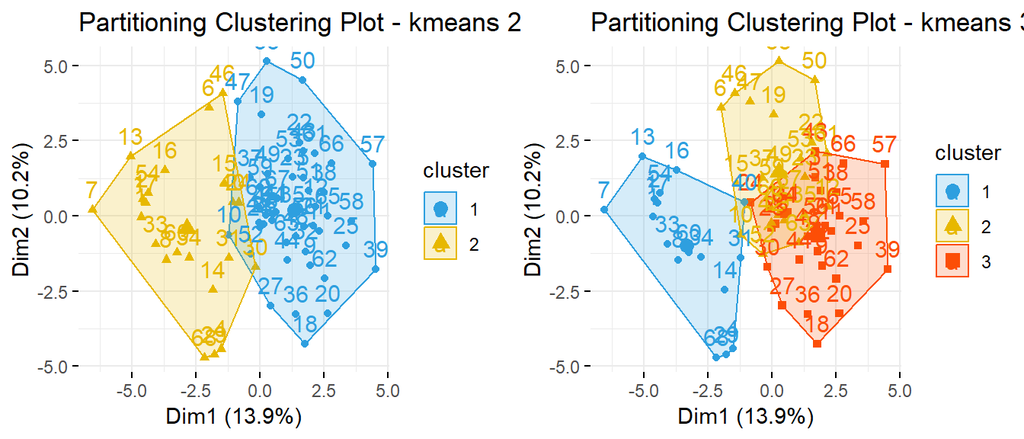

**PAM**

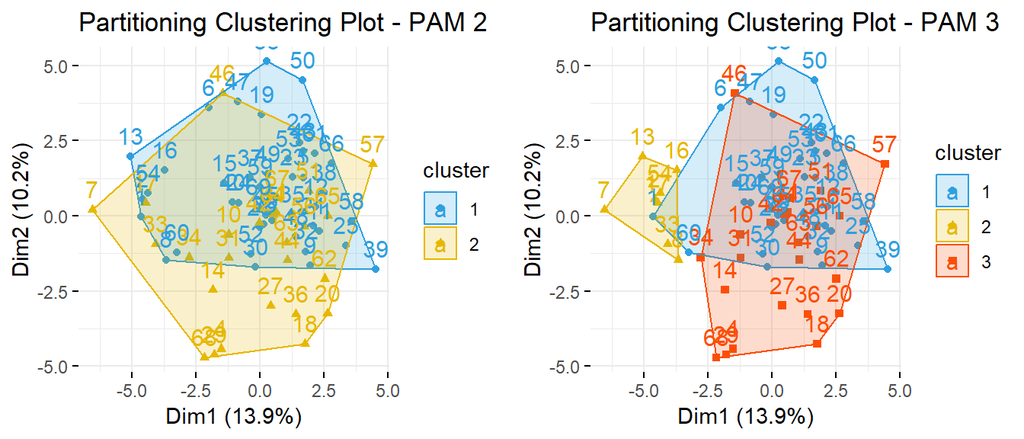

**Metoady hierarchiczne**

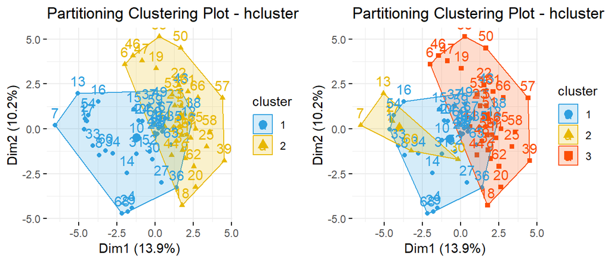

Analizując otrzymane wyniki z wykresów oraz z wizualizacji klastrów, należy podjąć decyzje, według jakiej metody i jakiego podziału będziemy klasyfikować nasz zbiór. Najbardziej odpowiednim wariantem zdaje się być metoda k -średnich dla podziału na 2 grupy.